# Oke_COLR_2023_quality_filtering

Kevin Olsen

2024-10-17

```r
library(tidyverse)
library(magrittr)
library(readxl)
library(rubias)
library(knitr)
library(adegenet)
library(poppr)
library(splitstackshape)
library(pegas)
library(PopGenReport)
library(hierfstat)
```

Read in 2023 genotypes and marker info file. Note trailing comma on last column (marker Oke_216_222) causes parsing warning. Read in genotypes and remove trailing comma.

Read in 2013 - 2022 genotypes provided by ODFW & WDFW

```r
genos_0.1 <- read_csv("C:/Users/olsenk2/OneDrive - Oregon State University/Desktop/Chum 2023/GT-seq_genotyping_output/Oke23_GTs_0.1.csv")
```

```
## Warning: One or more parsing issues, call `problems()` on your data frame for details,
## e.g.:
##   dat <- vroom(...)
##   problems(dat)
```

```r
genos_0.1 %<>%
  mutate(Oke_u216_222 = case_when(Oke_u216_222 == 'GG,' ~ 'GG',
                                  Oke_u216_222 == '00,' ~ '00',
                                  Oke_u216_222 == 'GA,' ~ 'GA'))


BigCrGray<-read.csv("C:/Users/olsenk2/OneDrive - Oregon State University/Desktop/Chum 2023/WDFW materials/BigCreek2014_2022_GraysRiver2013_2022.csv", header = TRUE,row.names = NULL, na.strings = "", stringsAsFactors = F)
```

Look at which columns have sequencing information and which have genotypes.

```r
colnames(genos_0.1)
```

```
##   [1] "Sample"            "Raw Reads"         "On-Target Reads"
##   [4] "%On-Target"        "%GT"               "IFI"
##   [7] "Oke_ACOT_100"      "Oke_APOB_60"       "Oke_ATP5L_105"
##  [10] "Oke_AhR1_278"      "Oke_CATB_60"       "Oke_CD123_62"
##  [13] "Oke_CKS1_70"       "Oke_CKS_389"       "Oke_CO1A1_72"
##  [16] "Oke_CTR2_82"       "Oke_DBLOH_79"      "Oke_DCXR_87"
##  [19] "Oke_DM20_548"      "Oke_EF2_394"       "Oke_GNMT_100"
##  [22] "Oke_GPDH_191"      "Oke_H2AX_72"       "Oke_HP_182"
##  [25] "Oke_IL8r2_406"     "Oke_IL8r_272"      "Oke_KPNA2_87"
##  [28] "Oke_LAMP2_186"     "Oke_METK2_97"      "Oke_MLRN_63"
##  [31] "Oke_PDIA3_082"     "Oke_PDIA3_475"     "Oke_PPA2_635"
##  [34] "Oke_RAD10028_44"   "Oke_RAD10173_41"   "Oke_RAD10459_85"
##  [37] "Oke_RAD10591_67"   "Oke_RAD10676_50"   "Oke_RAD10719_31"
##  [40] "Oke_RAD11183_63"   "Oke_RAD11379_85"   "Oke_RAD11444_75"
##  [43] "Oke_RAD11500_80"   "Oke_RAD11690_33"   "Oke_RAD11918_57"
```

[output cut: 104 more lines]

```r
kable(genos_0.1[1:5, 1:10])
```

| Sample | Raw Reads | On-Target Reads | %On-Target | %GT | IFI | Oke_ACOT_100 | Oke_APOB_60 | Oke_ATP5L_105 | Oke_AhR1_278 |
| --- | --- | --- | --- | --- | --- | --- | --- | --- | --- |
| negative1_S671_R1_001 | 44692 | 794 | 1.78 | 2.86 | 3.15 | 00 | 00 | 00 | 00 |
| negative2_S95_R1_001 | 20118 | 705 | 3.50 | 3.14 | 4.30 | 00 | 00 | 00 | 00 |
| negative3_S191_R1_001 | 20733 | 1191 | 5.74 | 5.43 | 1.56 | 00 | 00 | 00 | 00 |
| negative4_S479_R1_001 | 93316 | 497 | 0.53 | 0.29 | 0.00 | 00 | 00 | 00 | 00 |
| negative5_S575_R1_001 | 23638 | 125 | 0.53 | 0.00 | 0.00 | 00 | 00 | 00 | 00 |

First 6 columns have sample name and sequencing information. Columns 7 - 356 are markers with genotypes.

The following is code from WDFW: WDFW Rmarkdown removes X.GenoSuccess and LocusCount columns. Remove them.

WDFW Rmarkdown removes samples from outmigrant fry populations and outplants in 2013 and 2014. Remove them.

Look at which columns have metadata and which have genotypes.

```r
BigCrGray <- subset(BigCrGray, select = -c(X.GenoSuccess, LocusCount))

tmp <- BigCrGray %>% filter (year != "2013" , year != "2014")
dim(tmp)
```

```
## [1] 3252  357
```

```r
tmp1 <- BigCrGray %>% filter (year == "2013" & population %in% "GraysRiverHatchery"| year == "2014" & population %in% "GraysRiverHatchery")
dim(tmp1)
```

```
## [1] 270 357
```

```r
tmp2<- rbind(tmp, tmp1)
dim(tmp2)
```

```
## [1] 3522  357
```

```r
tmp3<- tmp2 %>% filter (!population %in% "Outmigrant")
dim(tmp3)
```

```
## [1] 3489  357
```

```r
WDFWgeno_df<-tmp3
rownames(WDFWgeno_df)<-tmp3$sample_name

colnames(WDFWgeno_df)
```

```
##   [1] "sample_name"       "WDFWcode"          "year"
##   [4] "origin"            "sex"               "population"
##   [7] "location"          "Oke_ACOT_100"      "Oke_APOB_60"
##  [10] "Oke_ATP5L_105"     "Oke_AhR1_278"      "Oke_CATB_60"
##  [13] "Oke_CD123_62"      "Oke_CKS1_70"       "Oke_CKS_389"
##  [16] "Oke_CO1A1_72"      "Oke_CTR2_82"       "Oke_DBLOH_79"
##  [19] "Oke_DCXR_87"       "Oke_DM20_548"      "Oke_EF2_394"
##  [22] "Oke_GNMT_100"      "Oke_GPDH_191"      "Oke_H2AX_72"
##  [25] "Oke_HP_182"        "Oke_IL8r2_406"     "Oke_IL8r_272"
##  [28] "Oke_KPNA2_87"      "Oke_LAMP2_186"     "Oke_METK2_97"
##  [31] "Oke_MLRN_63"       "Oke_PDIA3_082"     "Oke_PDIA3_475"
##  [34] "Oke_PPA2_635"      "Oke_RAD10028_44"   "Oke_RAD10173_41"
##  [37] "Oke_RAD10459_85"   "Oke_RAD10591_67"   "Oke_RAD10676_50"
##  [40] "Oke_RAD10719_31"   "Oke_RAD11183_63"   "Oke_RAD11379_85"
##  [43] "Oke_RAD11444_75"   "Oke_RAD11500_80"   "Oke_RAD11690_33"
```

[output cut: 104 more lines]

```r
kable(WDFWgeno_df[1:5, 1:10])
```

|  | sample_name | WDFWcode | year | origin | sex | population | location | Oke_ACOT_100 | Oke_APOB_60 | Oke_ATP5L_105 |
| --- | --- | --- | --- | --- | --- | --- | --- | --- | --- | --- |
| 15TN0005 | 15TN0005 | 15TN | 2015 | Hatchery | F | BigCreekBroodstock | NA | 0 | CT | CG |
| 15TN0006 | 15TN0006 | 15TN | 2015 | Unknown | F | BigCreekBroodstock | NA | 0 | 0 | 0 |
| 15TN0007 | 15TN0007 | 15TN | 2015 | Unknown | F | BigCreekBroodstock | NA | CC | TT | CG |
| 15TN0012 | 15TN0012 | 15TN | 2015 | Hatchery | F | BigCreekBroodstock | NA | 0 | CT | 0 |
| 15TN0014 | 15TN0014 | 15TN | 2015 | Hatchery | F | BigCreekBroodstock | NA | 0 | CT | 0 |

First 7 columns have metadata. Columns 8 - 357 are markers with genotypes.

Check if markers have the same names and are in same order in the two dataframes.

```r
identical(colnames(WDFWgeno_df)[8:ncol(WDFWgeno_df)], colnames(genos_0.1)[7:356])
```

```
## [1] TRUE
```

Clean up sample name in SFGL dataframe.

```r
genos_0.1 %<>%
  mutate(adapter = str_extract(Sample, "[ATCG]{6}-[ATCG]{6}")) %>%
  mutate(sample_simple = str_extract(Sample, "[:upper:][:lower:]{2}[AJCU][RC]\\d{2}\\w{4}_\\d{4}")) %>%
  relocate(Sample, sample_simple, adapter)
```

Create new column to identify negative and spiked positive controls. Sum negative and spiked positive controls and samples.

```r
genos_0.1 %<>%
  mutate(control = case_when(str_detect(Sample, "positive") ~ "positive",
                             str_detect(Sample, "Positive") ~ "positive",
                             str_detect(Sample, "Negative") ~ "negative",
                             str_detect(Sample, "negative") ~ "negative",
                             TRUE ~ "sample"))
kable(table(genos_0.1$control), col.names = c("Type", "Count"))
```

| Type | Count |
| --- | --- |
| negative | 7 |
| positive | 7 |
| sample | 659 |

Plot %On-Target reads in controls and samples

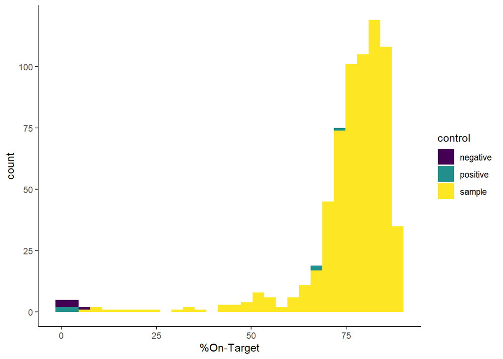

```r
ggplot()+geom_histogram(data = genos_0.1, aes(x = `%On-Target`, fill = control)) + theme_classic()+scale_fill_viridis_d()
```

Negative controls have very low % of reads that are on target. Good. Looks like a couple of the spiked positive controls didn’t amplify, but that’s not uncommon. Fine.

Remove spiked positive and negative controls, and “Undetermined” row (all unassigned reads get chunked into this row). Remove control column.

```r
genos_0.1 %<>%
  filter(control == "sample") %>%
  filter(!sample_simple == "Undetermined_S0_R1_001") %>%
  select(-control)
```

SFGL also does replicate positive controls, where a single sample is extracted and genotyped twice. Lets identify these and look at genotypic concordance. Note this grabs the two samples with the highest number of on target reads.

```r
genos_0.1 %<>%
  group_by(sample_simple) %>%
  slice_max(order_by = `On-Target Reads`, n = 2)

dups <- genos_0.1[genos_0.1$sample_simple %in% genos_0.1$sample_simple[duplicated(genos_0.1$sample_simple)],]
dups <- dups[order(dups$sample_simple),]

dim(dups)
```

```
## [1] 206 358
```

103 pairs of replicate positive controls (206 total samples).

Grab just the genotypes and measure concordance with a nested for loop. Plot concordance. Quantify range of concordance.

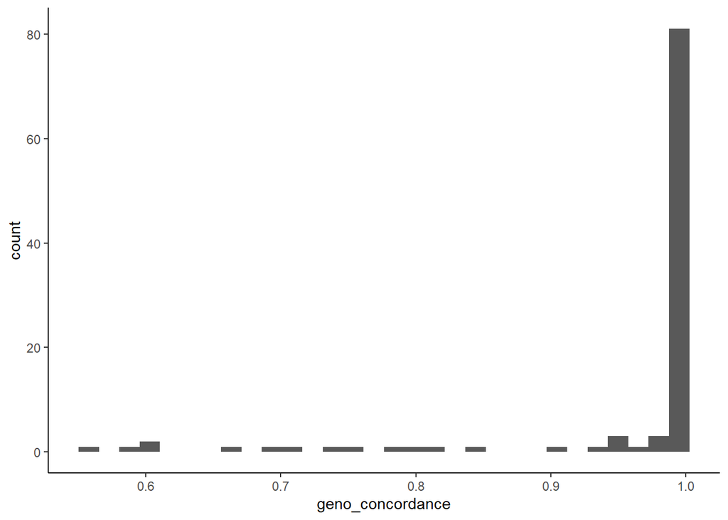

```r
dups_genos <- dups[,9:ncol(dups)]

rep_info <- matrix(ncol=ncol(dups_genos), nrow=nrow(dups_genos)/2)
colnames(rep_info) <- colnames(dups_genos)
for (j in 1:(nrow(dups_genos)/2)) {
  for (i in 1:ncol(dups_genos)) {
    rep_info[j,i] <- sum(dups_genos[(j*2)-1,i]==dups_genos[(j*2),i])
  }
}

geno_concordance <- as.data.frame(as.matrix(rep_info)) %>%
  rowMeans()
rep_data <- as.data.frame(cbind(dups[c(1:length(geno_concordance))*2,1], geno_concordance))

ggplot(data=rep_data)+geom_histogram(aes(x=geno_concordance))+theme_classic()
```

```r
range(rep_data$geno_concordance)
```

```
## [1] 0.5628571 1.0000000
```

Concordance between quality controls and corresponding samples is high for most pairs, however some with lower concordance. Concordance ranges 0.56 - 1.0

Write a new dataset (0.2) by choosing the samples within duplicates and keeping the one with the highest number of on target reads.

```r
genos_0.2 <- genos_0.1 %>%
  group_by(sample_simple) %>%
  filter(`On-Target Reads` == max(`On-Target Reads`))
```

Look at number of adult, juvenile, and carcass sample types. Use SFGL naming scheme to identify adult (AC), juvenile (JC), and carcass (CC) samples.

```r
genos_0.2 %<>%
  mutate(stage = case_when(str_detect(sample_simple, "OkeJC") ~ 'juvenile',
                           str_detect(sample_simple, "OkeAC") ~ 'adult',
                           str_detect(sample_simple, "OkeCC") ~ 'carcass'
  ))


kable(table(genos_0.2$stage), col.names = c("Stage", "Count"))
```

| Stage | Count |
| --- | --- |
| adult | 426 |
| carcass | 2 |
| juvenile | 127 |

Change SFGL dataframe format to match WDFW dataframe and fix location names in WDFW dataframe so we can combine them into a single df.

```r
genos_0.2 %<>%
  mutate(year = paste("20", substr(sample_simple, 6, 7), sep = "")) %>%
  mutate(location = case_when(str_detect(sample_simple, "BICH") == TRUE ~ 'BigCrHatchery',
                              str_detect(sample_simple, "GNCR") == TRUE ~ 'GnatCr',
                              str_detect(sample_simple, 'COCR') == TRUE ~ 'ConyersCr',
                              str_detect(sample_simple, 'COLR') == TRUE ~ 'BearCr',
                              str_detect(sample_simple, 'PAGC') == TRUE ~ 'PageCr',
                              str_detect(sample_simple, 'STCR') == TRUE ~ 'StewartCr',
                              str_detect(sample_simple, 'PLYC') == TRUE ~ 'PlymptonCr',
                              str_detect(sample_simple, 'CARC') == TRUE ~ 'CarcussCr',
                              str_detect(sample_simple, 'CLTR') == TRUE ~ 'Clatskanie'))

WDFWgeno_df %<>%
  mutate(location = case_when(location == 'ClatskanieR' ~ 'Clatskanie',
                              location == 'Clataskanie River' ~ 'Clatskanie',
                              location == 'Gnat Cr' ~ 'GnatCr',
                              location == 'Bear Cr' ~ 'BearCr',
                              location == 'Conyers Cr' ~ 'ConyersCr',
                              location == 'Page Creek' ~ 'PageCr',
                              location == 'Stewart Cr' ~ 'StewartCr',
))
```

SFGL dataset uses “00” as missing ; WDFW dataset uses “0” as missing. Change SFGL to “0”

```r
markers<-colnames(genos_0.2)[-c(1:8, 359:361)]

genos_0.2 %<>%
  mutate(across(markers,
                ~ case_when(. == '00' ~ '0',
                            TRUE ~ as.character(.))))
```

Load metadata for SFGL samples. Check sample names in metadata match those in the dataframe.

```r
SFGL_meta <- read_csv("C:/Users/olsenk2/OneDrive - Oregon State University/Desktop/Chum 2023/Chum23_meta.csv")
length(which(!genos_0.2$sample_simple %in% SFGL_meta$sample_name))
```

```
## [1] 0
```

Sample names in metadata match those in df. Put metadata into same row order as dataframe, then check they are in same order. Add metadata to dataframe.

```r
SFGL_meta<-SFGL_meta[order(match(SFGL_meta$sample_name, genos_0.2$sample_simple)), ]

identical(SFGL_meta$sample_name, genos_0.2$sample_simple)
```

```
## [1] TRUE
```

```r
genos_0.3<-cbind(genos_0.2, SFGL_meta)
```

Grab SFGL names (column 2), genotypes (columns 9 - 358), developmental stage, year, location, WDFW names, sex, population, length (columns 360 - 367).

```r
SFGLgeno_df<-as.data.frame(genos_0.3[, c(2, 9:358, 360:367)])
rownames(SFGLgeno_df)<-genos_0.3$sample_simple
```

Get WDFW code and name from comments column. Remove 2022 juvenile outmigrant fry samples so we can estimate genetic diversity among adult populations. Combine the SFGL and WDFW dataframes.

```r
SFGLgeno_df %<>%
  mutate(SFGL_name = sample_simple) %>%
  mutate(origin = 'NA') %>%
  mutate(WDFWcode = substr(COMMENTSGeneral, 12, 15)) %>%
  mutate(WDFWcode = case_when(WDFWcode == "" ~ '22ME',
                              WDFWcode == "SGS." ~ 'SGS.G23',
                              TRUE ~ as.character(WDFWcode))) %>%
  mutate(WDFW_name = substr(COMMENTSGeneral, 12, nchar(COMMENTSGeneral))) %>%
  mutate(WDFW_name = case_when(WDFW_name == "" ~ substr(COMMENTSGeneral, 1, 8),
                                 TRUE ~ as.character(WDFW_name))) %>%
  relocate(SFGL_name, WDFW_name, WDFWcode, year, origin, sex, population, location) %>%
  select(-c(sample_simple, sample_name, LengthFork1, LengthMEPS, COMMENTSGeneral)) %>%
  filter(!population == "Outmigrant")


WDFWgeno_df %<>%
  mutate(SFGL_name = 'NA') %>%
  mutate(WDFW_name = sample_name) %>%
  select(- sample_name) %>%
  mutate(population = case_when(population == "Adult Outplant" ~ 'Outplant',
                                TRUE ~ as.character(population))) %>%
  relocate(SFGL_name, WDFW_name)

combined_df<-rbind(SFGLgeno_df, WDFWgeno_df)
```

Calculate genotyping call rates for each marker. Remove markers genotyped in less than 30% of samples.

```r
missingness_marker <- as.data.frame(1 - (apply(combined_df[, 9:ncol(combined_df)], MARGIN = 2, function(x){ sum(x == 0 | x == 00)}) / nrow(combined_df)))
colnames(missingness_marker)<-"Proportion of Samples Genotyped"

missingness_marker %<>%
  rownames_to_column(var = 'Marker')

low_call_rates_marker<-as.data.frame(missingness_marker[which(missingness_marker$`Proportion of Samples Genotyped` < 0.3), ])
kable(low_call_rates_marker, row.names = FALSE)
```

| Marker | Proportion of Samples Genotyped |
| --- | --- |
| Oke_RDDFW35061_72 | 0.2596375 |
| Oke_RDDFW39550_74 | 0.2759765 |
| Oke_RDDFW91108_63 | 0.2826142 |
| Oke_RDDFW92495_48 | 0.2731682 |
| Oke_RDDFW92671_68 | 0.2729129 |
| Oke_RDDFW92833_41 | 0.2764871 |
| Oke_RDDFW93115_22 | 0.2708706 |
| Oke_RDDFW93316_60 | 0.2803166 |
| Oke_RDDFW95768_60 | 0.2792954 |
| Oke_RDDFW96549_63 | 0.2703600 |
| Oke_RDDFW97046_68 | 0.2634669 |
| Oke_RDDFW97566_28 | 0.2734235 |
| Oke_RDDFW97971_30 | 0.2703600 |
| Oke_RDDFW98640_53 | 0.2609140 |

Drop 14 markers with genotyping call rates below 30%.

```r
combined_df<-combined_df[, !colnames(combined_df) %in% low_call_rates_marker$Marker]
```

Convert dataframe to genind object to filter individuals using poppr (to match WDFW script/approach).

```r
genind <- df2genind(combined_df[, 9:ncol(combined_df)], sep ="", ploidy=2, NA.char = "0")
genind
```

```
## /// GENIND OBJECT /////////
##
##  // 3,840 individuals; 336 loci; 668 alleles; size: 10.3 Mb
##
##  // Basic content
##    @tab:  3840 x 668 matrix of allele counts
##    @loc.n.all: number of alleles per locus (range: 1-2)
##    @loc.fac: locus factor for the 668 columns of @tab
##    @all.names: list of allele names for each locus
##    @ploidy: ploidy of each individual  (range: 2-2)
##    @type:  codom
##    @call: df2genind(X = combined_df[, 9:ncol(combined_df)], sep = "", NA.char = "0",
##     ploidy = 2)
##
##  // Optional content
##    - empty -
```

77 samples with no scored loci were removed.

Remove samples genotyped at less than 35% of markers.

```r
genind_70clean <- missingno(genind, type = "geno", cutoff = 0.35, quiet = FALSE, freq = FALSE)
```

```
##
## Found 208113 missing values.
##
## 287 genotypes contained missing values greater than 35%
##
## Removing 287 genotypes: 15TN0012, 15TN0014, 15TN0022, 15TN0026,
## 15TM0226, 15TL0113, 15TL0114, 19QH0036, 19QI0057, 20LP0002, 20LP0208,
## 20MW0331, 20MW0416, 20MW0963, 20MW1001, 20MW1002, 20MW1020, 20MW1021,
## 20MW1024, 20MW1027, 20MW1068, 20MW1069, 20MW1073, 21MH0688, 21MH1063,
## 21MH0637, 21MH1288, 21MH0638, 21MH1148, 21MH0641, 21MH0695, 21MH1054,
## 21MH0693, 21MH1064, 21MH1087, 21MH0833, 21MH0401, 21MH1067, 21MH0457,
## 21MH0418, 21MH0809, 21MH0888, 21MH0811, 21MH1044, 21MH1575, 21MH1243,
## 21MH1045, 21MH1068, 21MH0694, 21MH1206, 21MH1056, 21MH0946, 21MH0003,
## 21MH0005, 21MH0006, 21MH0007, 21MH0009, 21MH0010, 21MH0014, 21MH0015,
## 21MH0016, 21MH0024, 21MH0025, 21MH0026, 21MH0030, 21MH0032, 21MH0033,
## 21MH0034, 21MH0039, 21MH0044, 21MH0045, 21MH0046, 21MH0048, 21MH0049,
## 21MH0050, 21MH0051, 21MH0052, 21MH0054, 21MH0055, 21MH0056, 21MH0057,
## 21MH0058, 21MH0060, 21MH0062, 21MH0063, 21MH0074, 21MH0075, 21MH0076,
## 21MH0077, 21MH0086, 21MH0091, 21MH0094, 21MH0098, 21MH0099, 21MH0103,
## 21MH0104, 21MH0106, 21MH0108, 21MH0116, 21MH0117, 21MH0120, 21MH0122,
## 21MH0123, 21MH0124, 21MH0125, 21MH0128, 21MH0130, 21MH0135, 21MH0137,
## 21MH0139, 21MH0142, 21MH0143, 21MH0144, 21MH0146, 21MH0147, 21MH0148,
## 21MH0149, 21MH0151, 21MH0152, 21MH0153, 21MH0154, 21MH0156, 21MH0157,
## 21MH0158, 21MH0159, 21MH0160, 21MH0161, 21MH0164, 21MH0172, 21MH0174,
## 21MH0182, 21MH0190, 21MH0194, 21MH0197, 21MH0226, 21MH0231, 18OD0093,
## 18OD0213, 18OD0215, 18OD0227, 19MW0099, 19MW0152, 19MW0153, 19MW0166,
## 20NB0060, 20NB0171, 20NB0178, 21MH0270, 21MH0276, 21MH0277, 21MH0305,
## 21MH0306, 21MH0307, 21MH0313, 21MH0316, 21MH0323, 21MH0325, 21MH0327,
## 21MH0336, 21MH0343, 21MH0354, 21MH0363, 21MH0379, 21MH0877, 21MH0613,
## 21MH1208, 21MH0480, 21MH0611, 21MH1520, 21MH1012, 21MI0019, 21MI0027,
## 21MI0048, 21MI6060, 21MI6067, 21MI6089, 21MI6121, 21MI6131, 21MI6139,
## 21MI6143, 21MI6149, 21MI7352, 21MI7363, 21MI7387, 21MI7452, 21MI7453,
## 21MI7458, 21MI7540, 21NR0004, 21NR0021, 21NR0050, 21NR0068, 21NR0183,
## 15TN0028, 15TN0029, 15TN0037, 15TN0102, 15TN0137, 15TN0166, 15TN0169,
## 16OU0035, 20LP0101, 20LP0133, 20LP0184, 21MH0507, 21MH0734, 21MH1473,
## 21MH0947, 21MH0953, 21MH0785, 21MH0759, 21MH0584, 21MH0721, 21MH0555,
## 21MH0726, 21MH1139, 21MH1016, 21MH0786, 21MH0725, 21MH0771, 21MH1474,
## 21MH1011, 21MH0573, 21MH1055, 18OD0063, 18OD0065, 18OD0118, 18OD0198,
## 18OD0226, 18OD0248, 19MW0022, 19MW0072, 19MW0111, 19MW0117, 19MW0143,
## 19MW0182, 20NB0052, 20NB0189, 21MH0727, 21MH1053, 21MH1559, 21MH1573,
## 21MI0017, 21MI0018, 21MI0025, 21MI0035, 21MI6023, 21MI6063, 21MI6071,
## 21MI6083, 21MI6093, 21MI6125, 21MI6141, 21MI6142, 21MI7374, 21MI7454,
## 21MI7456, 21NR0026, 21NR0057, 21NR0061, 21NR0070, 21NR0079, 21NR0135,
## 21NR0145, 18NF0022, 22LZ0015, 22LZ0027, 22LZ0030, 22LZ0096, 22LZ0132,
## 22LZ0141, 22LZ0157, 22LZ0295, 22LZ0393, 22MB0447, 22OV0003, 22OV0006,
## 22OV0125, 22OV0178, 22OV0182, 22OV0183, 22OV0184, 22OV0187, 22OV0190,
## 22OV0191, 22OV0192, 22OV0194
```

poppr removed 287 samples missing genotypes at more than 35% of markers.

Let’s check this manually.

```r
missingness_ind <- as.data.frame(apply(combined_df[, 9:ncol(combined_df)], MARGIN = 1, function(x){ sum(x == 0 | x == 00)}) / (ncol(combined_df)-8))
colnames(missingness_ind)<-"missing"

missingness_ind %<>%
  rownames_to_column(var = 'Ind')

low_call_rates_ind<-as.data.frame(missingness_ind[which(missingness_ind$missing > 0.35), ])

kable(low_call_rates_ind[1:5, ], row.names = FALSE)
```

| Ind | missing |
| --- | --- |
| 15TN0006 | 1.0000000 |
| 15TN0012 | 0.3779762 |
| 15TN0014 | 0.4375000 |
| 15TN0022 | 0.3601190 |
| 15TN0026 | 0.6279762 |

```r
dim(low_call_rates_ind)
```

```
## [1] 364   2
```

77 samples have no genotypes + 287 samples missing more than 35% of markers = 364 removed samples. So this looks correct.

Remove these 364 samples with low genotyping call rate and compare samples names in the filtered dataframe and filtered genind object. Note you can access sample names in genind objects with rownames(genind$tab).

```r
combined_df_70clean<-combined_df[!rownames(combined_df) %in% low_call_rates_ind$Ind, ]

identical(rownames(combined_df_70clean), rownames(genind_70clean$tab))
```

```
## [1] TRUE
```

Both filtering approaches result in the same 3,553 individuals genotyped with at least 65% of markers.

Convert dataframe to rubias format to check for duplicate sampling events. Here, we are looking for samples with different names but identical or nearly identical genotypes. SFGL SOP uses estimates of relatedness from the program coancestry to identify duplicates. WDFW script uses the R package rubias to do this.

The input file format for rubias requires one allele per column and integers rather than nucelotide letters. Add a delimiter, split genotype columns into two alleles, replace alleles with integers. Note some markers genotypes insertion/deletions (indels) represented with ‘-’. Also, set type.convert = FALSE otherwise the nucleotide T can be mistaken for “TRUE”. A = 1; T = 2; C = 3; G = 4; - = 5

```r
geno_cols<-colnames(combined_df_70clean)[-c(1:8)]

delim_gtypes <- as.data.frame(combined_df_70clean) %>%
  mutate(across(geno_cols,
                ~ case_when(. == "AA" ~ "A/A",
                            . == "AT" ~ "A/T",
                            . == "AC" ~ "A/C",
                            . == "AG" ~ "A/G",
                            . == "TT" ~ "T/T",
                            . == "TA" ~ "T/A",
                            . == "TC" ~ "T/C",
                            . == "TG" ~ "T/G",
                            . == "CC" ~ "C/C",
                            . == "CA" ~ "C/A",
                            . == "CT" ~ "C/T",
                            . == "CG" ~ "C/G",
                            . == "GG" ~ "G/G",
                            . == "GA" ~ "G/A",
                            . == "GT" ~ "G/T",
                            . == "GC" ~ "G/C",
                            . == "--" ~ "-/-",
                            . == "A-" ~ "A/-",
                            . == "T-" ~ "T/-",
                            . == "C-" ~ "C/-",
                            . == "G-" ~ "G/-",
                            . == "-A" ~ "-/A",
                            . == "-T" ~ "-/T",
                            . == "-C" ~ "-/C",
                            . == "-G" ~ "-/G",
                            . == "00" ~ "0/0",
                            . == "0" ~ "0/0"
                )))
dfspltgeno<-as.data.frame(cSplit(delim_gtypes, splitCols = geno_cols, sep = "/", type.convert = FALSE))
rownames(dfspltgeno)<-rownames(delim_gtypes)

geno_cols<-colnames(dfspltgeno)[-c(1:8)]

dfspltgeno %<>%
  mutate(across(geno_cols,
                ~ case_when(. == "A" ~ as.integer(1),
                            . == "T" ~ as.integer(2),
                            . == "C" ~ as.integer(3),
                            . == "G" ~ as.integer(4),
                            . == "-" ~ as.integer(5),
                            . == "0" ~ NA,
                )))
```

rubias requires certain metadata to run. This fake metadata is from the WDFW script. Add fake metadata to rubias formatted genotypes. Remove “_” from marker names for rubias.

```r
metadata<-data.frame(sample_type = "reference",
                     repunit = "test",
                     collection = "test",
                     indiv = rownames(dfspltgeno),
                     stringsAsFactors = FALSE)

genotypes_rubias<-cbind(metadata, dfspltgeno[, -c(1:8)])

colnames(genotypes_rubias[-1]) <- gsub("_", "", colnames(genotypes_rubias[-1]))
```

Identify duplicates IDs with increased cutoff to fraction matching = 0.97 and 0 for minimum fraction non missing.

```r
IDdupResults_0.97<-close_matching_samples(genotypes_rubias, gen_start_col=5,
                                     min_frac_non_miss = 0, min_frac_matching = 0.97)
```

```
## Summary Statistics:
##
## 3553 Individuals in Sample
##
## 336 Loci: Oke_ACOT_100_1, Oke_AhR1_278_1, Oke_APOB_60_1, Oke_arf_319_1, Oke_ATP5L_105_1, Oke_brd2_118_1, Oke_brp16_65_1, Oke_CATB_60_1, Oke_ccd16_77_1, Oke_CD123_62_1, Oke_cjo57_86_1, Oke_CKS_389_1, Oke_CKS1_70_1, Oke_CO1A1_72_1, Oke_ctgf_105_1, Oke_CTR2_82_1, Oke_DBLOH_79_1, Oke_DCXR_87_1, Oke_D…
##
## 1 Reporting Units: test
##
## 1 Collections: test
##
## 3.10% of allelic data identified as missing
```

```r
kable(IDdupResults_0.97[1:5, 1:4])
```

| num_non_miss | num_match | indiv_1 | indiv_2 |
| --- | --- | --- | --- |
| 241 | 235 | OkeAC23BICH_0041 | OkeAC23BICH_0141 |
| 252 | 245 | OkeAC23BICH_0047 | OkeAC23BICH_0141 |
| 329 | 329 | OkeAC23BICH_0102 | OkeAC23BICH_0103 |
| 330 | 329 | OkeAC23PAGC_0155 | OkeAC23PAGC_0156 |
| 282 | 282 | 15TN0150 | 15TN0157 |

```r
dim(IDdupResults_0.97)
```

```
## [1] 49 10
```

49 pairs of samples identified as duplicates with these rubias settings. Some samples involved in multiple duplicate pairs.

Write duplicates to csv file and pick which samples to remove.

```r
write.csv(IDdupResults_0.97, quote = FALSE, row.names = FALSE, file = "C:/Users/olsenk2/OneDrive - Oregon State University/Desktop/Chum 2023/Rubias_duplicates.csv")
```

Removing 44 samples from the dataframe and from genind object.

```r
to_remove<-c("OkeAC23BICH_0141", "OkeAC23BICH_0103", "OkeAC23PAGC_0156", "15TN0157", "20LP0010", "20LP0028", "20LP0029", "20MW1013", "21MH1574", "21MH1522", "13LL0003", "13LL0100",
             "13LL0117", "14OW0010", "14OW0028", "14OW0014", "14OW0207", "15PO0116", "17MA0076", "18OD0229", "19MW0013", "19MW0014", "20NB0024", "20NB0051", "21NR0024", "21NR0156",
             "19QH0051", "20LP0196", "21MH0586", "13LL0108", "14OW0017", "14OW0217", "18OD0221", "19MW0019", "19MW0178", "20NB0188", "21NR0075", "21NR0111", "22LZ0273", "22LZ0350",
             "22OV0044", "22OV0050", "22OV0106", "22OV0129")

combined_df_nodups<-combined_df_70clean[!rownames(combined_df_70clean) %in% to_remove, ]

genind_70clean_noDupes <- genind_70clean[!rownames(genind_70clean@tab) %in% to_remove]
```

Add WDFW population identifier to genind object. First, check rows of genind and rows of dataframe are in same order.

```r
identical(rownames(genind_70clean_noDupes@tab), rownames(combined_df_nodups))
```

```
## [1] TRUE
```

```r
genind_70clean_noDupes@pop<-as.factor(combined_df_nodups$population)
```

Identify markers that are out of Hardy-Weinberg equilibrium (HWE) in 3 or more populations using the pegas package. seppop applies the HWE test (hw.test) separately to each population. Adjust p-values for multiple comparisons using false discovery rate. Grab markers names that are out HWE in each population, combine, and sum. I’m sure there’s a more elegant way to apply multiple comparison correction and tally these…  
This can be done with chi-square and exact tests. Chi-square first.

```r
hwe.pop <- seppop(genind_70clean_noDupes) %>% lapply(hw.test)

Bigcreek_adjusted<-as.data.frame(p.adjust(hwe.pop$BigCreekBroodstock[, 3], method = 'BH'))
s_Bigcreek<-which(Bigcreek_adjusted <= 0.05)
sig_Bigcreek<-rownames(hwe.pop$BigCreekBroodstock[s_Bigcreek, ])

Grays_adjusted<-as.data.frame(p.adjust(hwe.pop$GraysRiverHatchery[, 3], method = 'BH'))
s_Grays<-which(Grays_adjusted <= 0.05)
sig_Grays<-rownames(hwe.pop$GraysRiverHatchery[s_Grays, ])

outplant_adjusted<-as.data.frame(p.adjust(hwe.pop$Outplant[, 3], method = 'BH'))
s_outplant<-which(outplant_adjusted <= 0.05)
sig_outplant<-rownames(hwe.pop$Outplant[s_outplant, ])

RSI_adjusted<-as.data.frame(p.adjust(hwe.pop$`RSI Outplant`[, 3], method = 'BH'))
s_RSI<-which(RSI_adjusted <= 0.05)
sig_RSI<-rownames(hwe.pop$`RSI Outplant`[s_RSI, ])

spawner_adjusted<-as.data.frame(p.adjust(hwe.pop$SpawnerSurvey[, 3], method = 'BH'))
s_spawner<-which(spawner_adjusted <= 0.05)
sig_spawner<-rownames(hwe.pop$SpawnerSurvey[s_spawner, ])

unfedfry_adjusted<-as.data.frame(p.adjust(hwe.pop$`Unfed Fry Outplant`[, 3], method = 'BH'))
s_unfedfry<-which(unfedfry_adjusted <= 0.05)
sig_unfedfry<-rownames(hwe.pop$`Unfed Fry Outplant`[s_unfedfry, ])

sig_HWE<-c(sig_Bigcreek, sig_Grays, sig_outplant, sig_RSI, sig_spawner, sig_unfedfry)

sum_sig_HWE<-table(sig_HWE)

repeat_offenders_HWE<-subset(sum_sig_HWE, sum_sig_HWE >= 3)

list_rof_HWE<-rownames(repeat_offenders_HWE)

kable(hwe.pop$BigCreekBroodstock[1:5, ])
```

|  | chi^2 | df | Pr(chi^2 >) | Pr.exact |
| --- | --- | --- | --- | --- |
| Oke_ACOT_100 | 0.2337495 | 1 | 0.6287574 | 0.772 |
| Oke_APOB_60 | 1.9360869 | 1 | 0.1640940 | 0.162 |
| Oke_ATP5L_105 | 0.1819091 | 1 | 0.6697377 | 0.684 |
| Oke_AhR1_278 | 0.1554841 | 1 | 0.6933487 | 0.655 |
| Oke_CATB_60 | 0.0095479 | 1 | 0.9221601 | 1.000 |

```r
list_rof_HWE
```

```
## [1] "Oke_RAD3143_30"    "Oke_RAD3907_37"    "Oke_RAD7512_33"
## [4] "Oke_RDDFW16781_68" "Oke_RDDFW39056_71" "Oke_RDDFW41741_28"
## [7] "Oke_RDDFW91049_44"
```

Chi-square test identified 7 markers that are of HWE in 3 or more populations.

Look at the exact test which is just in column 4 (Chi-square is in column 3).

```r
Bigcreek_adjusted_exact<-as.data.frame(p.adjust(hwe.pop$BigCreekBroodstock[, 4], method = 'BH'))
s_Bigcreek_exact<-which(Bigcreek_adjusted_exact <= 0.05)
sig_Bigcreek_exact<-rownames(hwe.pop$BigCreekBroodstock[s_Bigcreek_exact, ])

Grays_adjusted_exact<-as.data.frame(p.adjust(hwe.pop$GraysRiverHatchery[, 4], method = 'BH'))
s_Grays_exact<-which(Grays_adjusted_exact <= 0.05)
sig_Grays_exact<-rownames(hwe.pop$GraysRiverHatchery[s_Grays_exact, ])

outplant_adjusted_exact<-as.data.frame(p.adjust(hwe.pop$Outplant[, 4], method = 'BH'))
s_outplant_exact<-which(outplant_adjusted_exact <= 0.05)
sig_outplant_exact<-rownames(hwe.pop$Outplant[s_outplant_exact, ])

RSI_adjusted_exact<-as.data.frame(p.adjust(hwe.pop$`RSI Outplant`[, 4], method = 'BH'))
s_RSI_exact<-which(RSI_adjusted_exact <= 0.05)
sig_RSI_exact<-rownames(hwe.pop$`RSI Outplant`[s_RSI_exact, ])

spawner_adjusted_exact<-as.data.frame(p.adjust(hwe.pop$SpawnerSurvey[, 4], method = 'BH'))
s_spawner_exact<-which(spawner_adjusted_exact <= 0.05)
sig_spawner_exact<-rownames(hwe.pop$SpawnerSurvey[s_spawner_exact, ])

unfedfry_adjusted_exact<-as.data.frame(p.adjust(hwe.pop$`Unfed Fry Outplant`[, 4], method = 'BH'))
s_unfedfry_exact<-which(unfedfry_adjusted_exact <= 0.05)
sig_unfedfry_exact<-rownames(hwe.pop$`Unfed Fry Outplant`[s_unfedfry_exact, ])

sig_HWE_exact<-c(sig_Bigcreek_exact, sig_Grays_exact, sig_outplant_exact, sig_RSI_exact, sig_spawner_exact, sig_unfedfry_exact)

sum_sig_HWE_exact<-table(sig_HWE_exact)

repeat_offenders_HWE_exact<-subset(sum_sig_HWE_exact, sum_sig_HWE_exact >= 3)

list_of_HWE_exact<-rownames(repeat_offenders_HWE_exact)

list_of_HWE_exact
```

```
## [1] "Oke_RAD3143_30"    "Oke_RAD3907_37"    "Oke_RAD7512_33"
## [4] "Oke_RDDFW16781_68" "Oke_RDDFW39056_71" "Oke_RDDFW41741_28"
## [7] "Oke_RDDFW91049_44"
```

Exact test identifies the same 7 markers that the chi-square test identified.

Identify markers that didn’t genotype in any samples within a population/year combination with the package Popgenreport. Make new column with population and year combined. Convert to genind object and add pop/year as identifier.

```r
year_collection <- combined_df_nodups %>%
  mutate(pop_year = paste(population, substr(year, 3, 4), sep = "_")) %>%
  relocate(SFGL_name, WDFW_name, WDFWcode, year, origin, sex, population, location, pop_year)

year_collection_genind <- df2genind(year_collection[, 10:ncol(year_collection)], sep ="", ploidy=2, NA.char = "0")

year_collection_genind$pop<-as.factor(year_collection$pop_year)

year_collection_genind
```

```
## /// GENIND OBJECT /////////
##
##  // 3,509 individuals; 336 loci; 668 alleles; size: 9.4 Mb
##
##  // Basic content
##    @tab:  3509 x 668 matrix of allele counts
##    @loc.n.all: number of alleles per locus (range: 1-2)
##    @loc.fac: locus factor for the 668 columns of @tab
##    @all.names: list of allele names for each locus
##    @ploidy: ploidy of each individual  (range: 2-2)
##    @type:  codom
##    @call: df2genind(X = year_collection[, 10:ncol(year_collection)], sep = "",
##     NA.char = "0", ploidy = 2)
##
##  // Optional content
##    @pop: population of each individual (group size range: 2-335)
```

Use the allel.rich command to sum the number of times a marker is genotyped within each population and year. I silenced the warning that some markers are not genotyped within some pops/year. That’s what we are looking for.

```r
marker.richness<-allel.rich(year_collection_genind)
```

```
## Please see the pop.sizes matrix in the output list to identify the combinations of population and locus causing problems
```

```r
kable(marker.richness$pop.sizes[1:5, 1:5])
```

|  | BigCreekBroodstock_15 | BigCreekBroodstock_16 | BigCreekBroodstock_18 | BigCreekBroodstock_19 | BigCreekBroodstock_20 |
| --- | --- | --- | --- | --- | --- |
| Oke_ACOT_100 | 66 | 16 | 174 | 106 | 616 |
| Oke_APOB_60 | 70 | 16 | 176 | 104 | 608 |
| Oke_ATP5L_105 | 64 | 20 | 180 | 104 | 612 |
| Oke_AhR1_278 | 72 | 16 | 180 | 106 | 622 |
| Oke_CATB_60 | 72 | 18 | 180 | 106 | 622 |

Use apply to count the number of times a marker is genotyped 0 times within a population/year. Identify the markers where this happens at least once.

```r
no_call<-apply(marker.richness$pop.sizes, MARGIN = 1, function(x){ sum(x == "0") } )

which(no_call > 0)
```

```
##      Oke_KPNA2_87    Oke_RAD3143_30 Oke_RDDFW39056_71 Oke_RDDFW91049_44
##                21                73               158               245
##      Oke_RFC2_618    Oke_serpin_140
##               250               329
```

Oke_KPNA2_87, Oke_RAD3143_30, Oke_RDDFW39056_71, Oke_RDDFW91049_44, Oke_RFC2_618 , Oke_serpin_140 not genotyped in some pop/year combinations.

Identify markers with FIS less than -0.2 and greater than 0.2 with the pegas package.

```r
loci<-as.loci(genind_70clean_noDupes)
fst_results<- Fst(loci)

poor_fis<-subset(fst_results, fst_results[, 3] < -0.2 | fst_results[, 3] > 0.2)

list_of_FIS<-rownames(poor_fis)

kable(fst_results[1:5, ])
```

|  | Fit | Fst | Fis |
| --- | --- | --- | --- |
| Oke_ACOT_100 | -0.0128069 | -0.0006349 | -0.0121643 |
| Oke_APOB_60 | -0.0332026 | 0.0019064 | -0.0351761 |
| Oke_ATP5L_105 | -0.0164936 | -0.0006693 | -0.0158138 |
| Oke_AhR1_278 | -0.0180396 | -0.0009003 | -0.0171239 |
| Oke_CATB_60 | -0.0008592 | 0.0008953 | -0.0017562 |

```r
list_of_FIS
```

```
## [1] "Oke_RAD3143_30"    "Oke_RAD3907_37"    "Oke_RDDFW39056_71"
## [4] "Oke_RDDFW41741_28" "Oke_RDDFW91049_44"
```

5 markers with FIS outside of -0.2 to 0.2 range: “Oke_RAD3143_30” “Oke_RAD3907_37” “Oke_RDDFW39056_71” “Oke_RDDFW41741_28” “Oke_RDDFW91049_44”.

Make a list of markers that are out of HWE, bad FIS, or weren’t genotyped in certain populations/years to remove. Remove them from dataframe and genind object.

```r
markers_to_drop<-unique(c(list_rof_HWE, list_of_FIS, "Oke_KPNA2_87", "Oke_RAD3143_30", "Oke_RDDFW39056_71", "Oke_RDDFW91049_44", "Oke_RFC2_618", "Oke_serpin_140"))

combined_df_filtered<-combined_df_nodups[, !colnames(combined_df_nodups) %in% markers_to_drop]

markers_to_keep<-setdiff(locNames(genind_70clean_noDupes), markers_to_drop)

genind_filtered<-genind_70clean_noDupes[loc = markers_to_keep]
```

Identify all 24 markers dropped during filtering

```r
markers_350<-colnames(genos_0.1)[-c(1:8)]

markers_filtered<-colnames(combined_df_filtered)[-c(1:8)]

dropped<-markers_350[!markers_350 %in% markers_filtered]

kable(dropped)
```

| x |
| --- |
| Oke_KPNA2_87 |
| Oke_RAD3143_30 |
| Oke_RAD3907_37 |
| Oke_RAD7512_33 |
| Oke_RDDFW16781_68 |
| Oke_RDDFW35061_72 |
| Oke_RDDFW39056_71 |
| Oke_RDDFW39550_74 |
| Oke_RDDFW41741_28 |
| Oke_RDDFW91049_44 |
| Oke_RDDFW91108_63 |
| Oke_RDDFW92495_48 |
| Oke_RDDFW92671_68 |
| Oke_RDDFW92833_41 |
| Oke_RDDFW93115_22 |
| Oke_RDDFW93316_60 |
| Oke_RDDFW95768_60 |
| Oke_RDDFW96549_63 |
| Oke_RDDFW97046_68 |
| Oke_RDDFW97566_28 |
| Oke_RDDFW97971_30 |
| Oke_RDDFW98640_53 |
| Oke_RFC2_618 |
| Oke_serpin_140 |

```r
length(dropped)
```

```
## [1] 24
```

Filtered dataset has 3,509 individuals and 326 markers. Save filtered dataframe as an R object.

```r
save(combined_df_filtered, file = "C:/Users/olsenk2/OneDrive - Oregon State University/Desktop/Chum 2023/Oke_filtered.R")
```